# Master M2 MVA 2014/2015 - Graphical models

Mohamed N'AITN'BARK

```python
import networkx as ntx
%pylab inline
```

## 1 Distributions factorizing in a graph

**(a)**

- For a node $k \in E$ we denote $\pi_k$ the set of its parents in E and $\pi'_k$ the set of tis parents in $E'$.  
  Let $p \in L(G)$, $p(x) = \prod_{k \in V}{p(x_k|x_{\pi_k})} = p(x_i|x_{\pi_i})p(x_j|x_{\pi_j})\prod_{k \in V-\{i,j\}}{p(x_k|x_{\pi_k})}$  
  For $p \in L(G')$ $p(x) = \prod_{k \in V}{p(x_k|x_{\pi'_k})} = p(x_i|x_{\pi'_i})p(x_j|x_{\pi'_j})\prod_{k \in V-\{i,j\}}{p(x_k|x_{\pi_k})}$ Since $\forall k \in V-\{i,j\}: \pi_k = \pi'_k$  
  $E' = (E-\{(i,j)\}) \cup \{(j,i)\}$ and $\pi_j = \pi_i \cup \{i\}$ implies that:  
  $\pi'_j = \pi_i$ and $\pi'_i = \pi'_j \cup \{j\} = \pi_i \cup \{j\}$  
  To show that $L(G) = L(G')$ we need only to show that $p(x_i|x_{\pi_i})p(x_j|x_{\pi_j}) = p(x_i|x_{\pi'_i})p(x_j|x_{\pi'_j})$  
  $p(x_i|x_{\pi'_i}) = p(x_i|x_{\pi_i}, x_j) = \frac{p(x_j|x_{\pi_i},x_i)p(x_i|x_{\pi_i})}{p(x_j|x_{\pi_i})} = \frac{p(x_j|x_{\pi_i \cup \{i\}})p(x_i|x_{\pi_i})}{p(x_j|x_{\pi'_j})} = \frac{p(x_j|x_{\pi_j})p(x_i|x_{\pi_i})}{p(x_j|x_{\pi'_j})}$  
  Therefore $p(x_i|x_{\pi_i})p(x_j|x_{\pi_j}) = p(x_i|x_{\pi'_i})p(x_j|x_{\pi'_j})$ and $L(G) = L(G')$
- $G = (V,E)$ a directed tree without v-structures, then $\forall i \in V, \pi_i$ is a singleton  
  Let C be a click of $G'$, suppose that C contain more than three elements, then we have one of the two situations:  
  i- C contain a v-structure, this can't be in our case.  
  ii- C doesn't contain any v-structures, in this case we have necessary a cycle which contradicts the fact that G is a tree.  
  Therefore all the cliques contain exactly two elements and are of the form $ {i} _i$  
  Let p be an element of $L(G')$:  
  $p(x) = \frac{1}{Z} \prod_{i \in V}\psi_{i}(x_i,x_{\pi_i})$ such that $\forall i \in V: \psi_i \geq 0$ and $Z = \sum_{x} \psi_i$ Therefore $p \in L(G)$ and $L(G) = L(G')$

**(b)**

## 2 d-separation

**(a)**

Let $a \in A$ and $b \in B$ and $H=(v_1,...,v_n)$ a chain s.t. $v_1 = a$ and $v_n = b$  
$\forall i \in [1,n] :$ if $v_i \in S$ then if $(v_{i-1},v_i,v_{i+1})$ is a v-structure $H-{v_i}$ is a path in $G_M$ from $a$ to $b$.  
Hence if $\forall i \in [1,n]$ s.t. $v_i \in S: (v_{i-1},v_i,v_{i+1})$ is a v-structure, we can recursively construct a path in $G_M$ where all the nodes are not elements of S, which contradicts the separation in $G_M$.  
Therefore if $H \cap S \neq \emptyset$ then $\exists d=v_i \in H \cap S$ s.t. $(v_{i-1},v_i,v_{i+1})$ is not a v-structure, which means that $H$ is blocked by S in d.  
$H \cap S \neq \emptyset$ because $A$ and $B$ are separated in $G_M$

**(b)**

Not necessarily, as a counter example we can consider the example below:

```
{1: <matplotlib.text.Text at 0x7fc3c361ac90>,
 2: <matplotlib.text.Text at 0x7fc3c3627e10>,
 3: <matplotlib.text.Text at 0x7fc3c3627310>,
 4: <matplotlib.text.Text at 0x7fc3c3627cd0>,
 5: <matplotlib.text.Text at 0x7fc3c363dfd0>,
 6: <matplotlib.text.Text at 0x7fc3c363dbd0>}
```

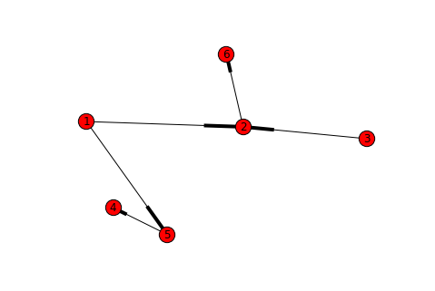

```python
graph = ntx.DiGraph()
graph.add_nodes_from([1,2,3,4,5,6])
graph.add_edges_from([(1,2),(2,6),(3,2),(1,5),(5,4)])
pos=ntx.spring_layout(graph)
labels = {i:i for i in [1,2,3,4,5,6]}
ntx.draw(graph, pos=pos, with_labels=False)
ntx.draw_networkx_labels(graph,pos, labels)
```

In the graph above, we have a counter example by considering $A=\{1\}, B=\{3\}, S=\{4\}$ and $T=\{5,6\}$

**(c)**

## 3 Implementation - Gaussian mixtures

```python
# Load data
train = loadtxt("EMGaussian.data", delimiter=" ")
test = loadtxt("EMGaussian.test", delimiter=" ")
alldata = vstack((train,test))
```

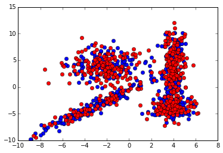

```python
# Visualize our data
plot(train[:,0],train[:,1],"bo",test[:,0],test[:,1],"ro")
```

We can observe four clusters

#### (a) K-mans algorithm:

```python
# Initial random centers
K = 4
centers = (0.5-rand(K,2))*array([8,10])
```

```python
def kmeans(train,centers):
    j=0
    K = shape(centers)[0]
    new_centers = zeros_like(centers)
    d = zeros((shape(train)[0],K))
    distortions = []
    while True:
        for k in range(0,K):
            d[:,k] = norm(train - centers[k,:], axis = 1)
        points_centers = argmin(d,axis=1)
        distortions.append((d**2).min(axis=1).sum())
        for k in range(0,K):
            new_centers[k,:] = mean(train[points_centers == k], axis=0)
        if (centers == new_centers).all():
            return (centers, points_centers, array(distortions))
        else:
            centers = copy(new_centers)
```

```python
new_centers,points_centers,distortions = kmeans(train, centers)
```

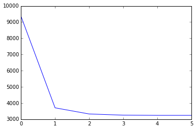

```python
plot(distortions)
```

The figure above represents the distortion at each step of the KMeans algorithm

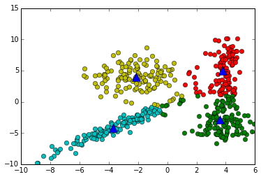

```python
plot(train[points_centers == 0,0],train[points_centers == 0,1],"co",
     train[points_centers == 1,0],train[points_centers == 1,1],"ro",
     train[points_centers == 2,0],train[points_centers == 2,1],"go",
     train[points_centers == 3,0],train[points_centers == 3,1],"yo")
plot(new_centers[:,0],new_centers[:,1],"b^",markersize=12)
```

The figure above represents the result of the KMeans for the training data

```python
# For different initializations:
max_it = 50
res = zeros((max_it,9))
for i in range(0,max_it):
    K = 4
    centers = (0.5-rand(K,2))*array([8,10])
    new_centers,points_centers,distortion = kmeans(train, centers)
    res[i,:-1] = new_centers.flatten()
    res[i,-1] = distortion[-1]
```

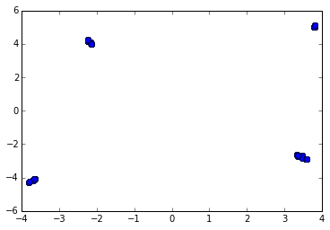

```python
plot(res[:,0],res[:,1],"bo",res[:,2],res[:,3],"bo",res[:,4],res[:,5],"bo",res[:,6],res[:,7],"bo")
```

The figure above represents the centers for each of the 50 different initializations

```python
print mean(res[:,-1])
print std(res[:,-1])
```

```
3239.62680144
1.19452370465
```

The value of the standard deviation of the distortion function shows that we converged towards the same minimal distortiona at each initialization

```python
from scipy.stats import multivariate_normal
from scipy.stats import norm as normal
```

```python
def em_gaussianmixture1(data, K, max_iter=1000):
    # Initialization:
    means = (0.5-rand(K,2))*array([8,10])
    means = kmeans(data,means)[0]
    variances = ones((K,2))
    p = repeat(1/float(K),K)
    resp = zeros((K,data.shape[0]))
    i=0
    # EM loop
    while i < max_iter:
        i = i + 1
        for k in range(0,K):
            resp[k,:] = p[k]*multivariate_normal.pdf(data, mean=means[k,:],cov=diag(variances[k,:]))
        resp = resp/resp.sum(axis=0)
        p = resp.mean(axis=1)
        resp = (resp.T/resp.sum(axis=1)).T
        means = resp.dot(data)
        for k in range(0,K):
            variances[k,:] = resp[k,:].dot((data - means[k,:])**2)
    return (p, means, variances)
```

```python
def gaussian_mixture_classify(data, p, means, covs):
    N = data.shape[0]
    d = p.shape[0]
    probs = zeros((N,d))
    for k in range(0,d):
        probs[:,k] = p[k]*multivariate_normal.pdf(data, mean=means[k,:],cov=covs[k])
    return argmax(probs, axis=1)
```

```python
K = 4
p1,means1,cov1 = em_gaussianmixture1(train, K)
```

```python
p1
```

```
array([ 0.14587219,  0.41069369,  0.25934528,  0.18408883])
```

```python
means1
```

```
array([[-5.04944266, -5.49394031],
       [-1.74315359,  1.82896759],
       [ 3.98503785,  3.85749997],
       [ 3.80781846, -3.77008527]])
```

```python
cov1
```

```
array([[  2.53678545,   2.59453719],
       [  2.88360185,  11.29568932],
       [  0.21589462,  11.64253093],
       [  0.85618867,   1.91513118]])
```

```python
latent = gaussian_mixture_classify(alldata, p1, means1, [diag(cov1[k,:]) for k in range(0,K)])
```

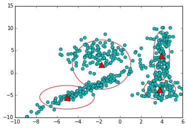

```python
X,Y = meshgrid(linspace(-10,6,50),linspace(-10,15,50))
Z1 = ((X-means1[0,0])**2)/cov1[0,0] + ((Y-means1[0,1])**2)/cov1[0,1] - normal.ppf(0.95)**2
Z2 = ((X-means1[1,0])**2)/cov1[1,0] + ((Y-means1[1,1])**2)/cov1[1,1] - normal.ppf(0.95)**2
Z3 = ((X-means1[2,0])**2)/cov1[2,0] + ((Y-means1[2,1])**2)/cov1[2,1] - normal.ppf(0.95)**2
Z4 = ((X-means1[3,0])**2)/cov1[3,0] + ((Y-means1[3,1])**2)/cov1[3,1] - normal.ppf(0.95)**2
plot(train[:,0],train[:,1],"co")
plot(means1[:,0],means1[:,1],"r^",markersize=12)
contour(X,Y,Z1,1, colors="r")
contour(X,Y,Z2,1, colors="r")
contour(X,Y,Z3,1, colors="r")
contour(X,Y,Z4,1, colors="r")
```

With on diagonal covaraince matrixes, we retrain to probablity density contours that have a conic form with axis corresponding to x=0 and y=0. This explains why this models fails to capture the cluster in the bottom left.

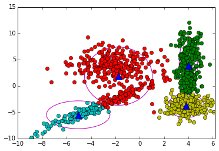

```python
X,Y = meshgrid(linspace(-10,6,50),linspace(-10,15,50))
Z1 = ((X-means1[0,0])**2)/cov1[0,0] + ((Y-means1[0,1])**2)/cov1[0,1] - normal.ppf(0.95)**2
Z2 = ((X-means1[1,0])**2)/cov1[1,0] + ((Y-means1[1,1])**2)/cov1[1,1] - normal.ppf(0.95)**2
Z3 = ((X-means1[2,0])**2)/cov1[2,0] + ((Y-means1[2,1])**2)/cov1[2,1] - normal.ppf(0.95)**2
Z4 = ((X-means1[3,0])**2)/cov1[3,0] + ((Y-means1[3,1])**2)/cov1[3,1] - normal.ppf(0.95)**2
plot(alldata[latent == 0,0],alldata[latent == 0,1],"co")
plot(alldata[latent == 1,0],alldata[latent == 1,1],"ro")
plot(alldata[latent == 2,0],alldata[latent == 2,1],"go")
plot(alldata[latent == 3,0],alldata[latent == 3,1],"yo")
plot(means1[:,0],means1[:,1],"b^",markersize=12)
contour(X,Y,Z1,1, colors="m")
contour(X,Y,Z2,1, colors="m")
contour(X,Y,Z3,1, colors="m")
contour(X,Y,Z4,1, colors="m")
```

This is the same model with all our data, the models is adapted to the two clusters in the right, but not to the two others

#### (c) EM algorithm for a gaussian mixture in the general case:

```python
def em_gaussianmixture2(data, K, max_iter=1000):
    # Initialization:
    means = (0.5-rand(K,2))*array([8,10])
    means = kmeans(data,means)[0]
    cov = [diag([1,1]) for i in range(0,4)]
    p = repeat(1/float(K),K)
    resp = zeros((K,data.shape[0]))
    i=0
    # EM loop
    while i < max_iter:
        i = i + 1
        for k in range(0,K):
            resp[k,:] = p[k]*multivariate_normal.pdf(data, mean=means[k,:],cov=cov[k])
        resp = resp/resp.sum(axis=0)
        p = resp.mean(axis=1)
        resp = (resp.T/resp.sum(axis=1)).T
        means = resp.dot(data)
        for k in range(0,K):
            cov[k] = (resp[k,:]*((data - means[k,:]).T)).dot(data - means[k,:])
    return (p, means, cov)
```

```python
p2,means2,cov2 = em_gaussianmixture2(train, K=4)
```

```python
p2
```

```
array([ 0.25155719,  0.18290156,  0.25998574,  0.30555552])
```

```python
means2
```

```
array([[-2.03436695,  4.17258596],
       [ 3.80070949, -3.79729742],
       [ 3.97793025,  3.77333059],
       [-3.06196072, -3.53454048]])
```

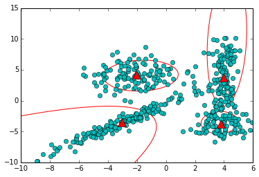

```python
X,Y = meshgrid(linspace(-10,6,50),linspace(-10,15,50))
inv_cov = [inv(cov2[k]) for k in range(0,K)]
Z1 = ((X-means2[0,0])**2)*inv_cov[0][0,0] + ((Y-means2[0,1])**2)*inv_cov[0][1,1] + 2*inv_cov[0][0,1]*X*Y - normal.ppf(0.95)**2
Z2 = ((X-means2[1,0])**2)*inv_cov[1][0,0] + ((Y-means2[1,1])**2)*inv_cov[1][1,1] + 2*inv_cov[1][0,1]*X*Y - normal.ppf(0.95)**2
Z3 = ((X-means2[2,0])**2)*inv_cov[2][0,0] + ((Y-means2[2,1])**2)*inv_cov[2][1,1] + 2*inv_cov[2][0,1]*X*Y - normal.ppf(0.95)**2
Z4 = ((X-means2[3,0])**2)*inv_cov[3][0,0] + ((Y-means2[3,1])**2)*inv_cov[3][1,1] + 2*inv_cov[3][0,1]*X*Y - normal.ppf(0.95)**2
plot(train[:,0],train[:,1],"co")
plot(means2[:,0],means2[:,1],"r^",markersize=12)
contour(X,Y,Z1,1, colors="r")
contour(X,Y,Z2,1, colors="r")
contour(X,Y,Z3,1, colors="r")
contour(X,Y,Z4,1, colors="r")
```

For the training data, we see that the models captures well our clusters.

```python
latent2 = gaussian_mixture_classify(alldata, p2, means2, cov2)
```

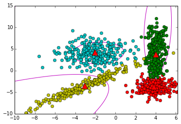

```python
X,Y = meshgrid(linspace(-10,6,50),linspace(-10,15,50))
inv_cov = [inv(cov2[k]) for k in range(0,K)]
Z1 = ((X-means2[0,0])**2)*inv_cov[0][0,0] + ((Y-means2[0,1])**2)*inv_cov[0][1,1] + 2*inv_cov[0][0,1]*X*Y - normal.ppf(0.95)**2
Z2 = ((X-means2[1,0])**2)*inv_cov[1][0,0] + ((Y-means2[1,1])**2)*inv_cov[1][1,1] + 2*inv_cov[1][0,1]*X*Y - normal.ppf(0.95)**2
Z3 = ((X-means2[2,0])**2)*inv_cov[2][0,0] + ((Y-means2[2,1])**2)*inv_cov[2][1,1] + 2*inv_cov[2][0,1]*X*Y - normal.ppf(0.95)**2
Z4 = ((X-means2[3,0])**2)*inv_cov[3][0,0] + ((Y-means2[3,1])**2)*inv_cov[3][1,1] + 2*inv_cov[3][0,1]*X*Y - normal.ppf(0.95)**2
plot(alldata[latent2 == 0,0],alldata[latent2 == 0,1],"co")
plot(alldata[latent2 == 1,0],alldata[latent2 == 1,1],"ro")
plot(alldata[latent2 == 2,0],alldata[latent2 == 2,1],"go")
plot(alldata[latent2 == 3,0],alldata[latent2 == 3,1],"yo")
plot(means2[:,0],means2[:,1],"r^",markersize=12)
contour(X,Y,Z1,1, colors="m")
contour(X,Y,Z2,1, colors="m")
contour(X,Y,Z3,1, colors="m")
contour(X,Y,Z4,1, colors="m")
```

The general gaussian mixture model appears to perform well on the test data, we can confirm that by calculating the loglikelihood

```python
def gaussian_mixture_loglikelihood(data,means, cov, p):
    K = p.size
    dens = zeros((data.shape[0], K))
    for k in range(0,K):
        dens[:,k] = multivariate_normal.pdf(data, mean=means[k,:], cov=cov[k])
    dens = dens.dot(p)
    return log(dens).sum()
```

```python
#Loglikelihood for first model on training data
gaussian_mixture_loglikelihood(train, means1, cov1, p1)
```

```
-2512.609088422998
```

```python
#Loglikelihood for first model on test data
gaussian_mixture_loglikelihood(test, means1, cov1, p1)
```

```
-2466.9437054385917
```

```python
#Loglikelihood for second model on training data
gaussian_mixture_loglikelihood(train, means2, cov2, p2)
```

```
-2327.7156749216497
```

```python
#Loglikelihood for second model on test data
gaussian_mixture_loglikelihood(test, means2, cov2, p2)
```

```
-2408.9781534532626
```